# Multi omics analysis by MOFA and GLUE

MOFA is a factor analysis model that provides a general framework for the integration of multi-omic data sets in an unsupervised fashion.

Most of the time, however, we did not get paired cells in the multi-omics analysis. Here, we can pair cells using GLUE, a dimensionality reduction algorithm that can integrate different histological layers, and it can efficiently merge data from different histological layers.

This tutorial focuses on how to perform mofa in multi-omics using GLUE.

Paper: [MOFA+: a statistical framework for comprehensive integration of multi-modal single-cell data](https://genomebiology.biomedcentral.com/articles/10.1186/s13059-020-02015-1) and [Multi-omics single-cell data integration and regulatory inference with graph-linked embedding](https://www.nature.com/articles/s41587-022-01284-4)

Code: https://github.com/bioFAM/mofapy2 and https://github.com/gao-lab/GLUE

Colab_Reproducibility：https://colab.research.google.com/drive/1zlakFf20IoBdyuOQDocwFQHu8XOVizRL?usp=sharing

We used the result anndata object `rna-emb.h5ad` and `atac.emb.h5ad` from [GLUE'tutorial](https://scglue.readthedocs.io/en/latest/training.html)

```python
import omicverse as ov
ov.utils.ov_plot_set()
```

import omicverse as ov ov.utils.ov_plot_set()

[output not shown]

```
/mnt/data/env/pyomic/lib/python3.8/site-packages/phate/__init__.py
```

## Load the data

We use `ov.utils.read` to read the `h5ad` files

```python
rna=ov.utils.read("chen_rna-emb.h5ad")
atac=ov.utils.read("chen_atac-emb.h5ad")
```

rna=ov.utils.read("chen_rna-emb.h5ad") atac=ov.utils.read("chen_atac-emb.h5ad")

## Pair the omics

Each cell in our rna and atac data has a feature vector, X_glue, based on which we can calculate the Pearson correlation coefficient to perform cell matching.

```python
pair_obj=ov.single.GLUE_pair(rna,atac)
pair_obj.correlation()
```

pair_obj=ov.single.GLUE_pair(rna,atac) pair_obj.correlation()

```
......Extract GLUE layer from obs
......Prepare for pair
......Start to calculate the Pearson coef
```

```
Now rna_index is 4999/9999, all is 9190: 100%|█████████████████████████████████████████████████████████████| 5000/5000 [01:00<00:00, 82.59it/s]
```

```
Now epoch is 0, 5000/9190
```

```
Now rna_index is 9189/13379, all is 9190: 100%|████████████████████████████████████████████████████████████| 4190/4190 [00:58<00:00, 71.04it/s]
```

```
Now epoch is 1, 9190/9190
```

```python
res_pair=pair_obj.find_neighbor_cell(depth=20)
res_pair.to_csv('models/chen_pair_res.csv')
```

res_pair=pair_obj.find_neighbor_cell(depth=20) res_pair.to_csv('models/chen_pair_res.csv')

We filter to get paired cells

```python
rna1=rna[res_pair['omic_1']]
atac1=atac[res_pair['omic_2']]
rna1.obs.index=res_pair.index
atac1.obs.index=res_pair.index
rna1,atac1
```

rna1=rna[res_pair['omic_1']] atac1=atac[res_pair['omic_2']] rna1.obs.index=res_pair.index atac1.obs.index=res_pair.index rna1,atac1

```
(View of AnnData object with n_obs × n_vars = 5802 × 28930
     obs: 'domain', 'cell_type', 'balancing_weight'
     var: 'highly_variable', 'highly_variable_rank', 'means', 'variances', 'variances_norm', 'mean', 'std', 'chrom', 'chromStart', 'chromEnd', 'name', 'score', 'strand', 'thickStart', 'thickEnd', 'itemRgb', 'blockCount', 'blockSizes', 'blockStarts', 'gene_id', 'gene_type', 'mgi_id', 'havana_gene', '…
     uns: '__scglue__', 'cell_type_colors', 'hvg', 'log1p', 'neighbors', 'pca', 'umap'
     obsm: 'X_glue', 'X_pca', 'X_umap'
     varm: 'PCs', 'X_glue'
     layers: 'counts'
     obsp: 'connectivities', 'distances',
 View of AnnData object with n_obs × n_vars = 5802 × 241757
     obs: 'domain', 'cell_type', 'balancing_weight'
     var: 'chrom', 'chromStart', 'chromEnd', 'highly_variable'
     uns: '__scglue__', 'cell_type_colors', 'neighbors', 'umap'
     obsm: 'X_glue', 'X_lsi', 'X_umap'
     varm: 'X_glue'
     obsp: 'connectivities', 'distances')
```

We can use mudata to store the multi-omics

```python
from mudata import MuData

mdata = MuData({'rna': rna1, 'atac': atac1})
mdata
```

from mudata import MuData mdata = MuData({'rna': rna1, 'atac': atac1}) mdata

```
MuData object with n_obs × n_vars = 5802 × 270687
  var:	'highly_variable', 'chrom', 'chromStart', 'chromEnd'
  2 modalities
    rna:	5802 x 28930
      obs:	'domain', 'cell_type', 'balancing_weight'
      var:	'highly_variable', 'highly_variable_rank', 'means', 'variances', 'variances_norm', 'mean', 'std', 'chrom', 'chromStart', 'chromEnd', 'name', 'score', 'strand', 'thickStart', 'thickEnd', 'itemRgb', 'blockCount', 'blockSizes', 'blockStarts', 'gene_id', 'gene_type', 'mgi_id', 'havana_gene', …
      uns:	'__scglue__', 'cell_type_colors', 'hvg', 'log1p', 'neighbors', 'pca', 'umap'
      obsm:	'X_glue', 'X_pca', 'X_umap'
      varm:	'PCs', 'X_glue'
      layers:	'counts'
      obsp:	'connectivities', 'distances'
    atac:	5802 x 241757
      obs:	'domain', 'cell_type', 'balancing_weight'
      var:	'chrom', 'chromStart', 'chromEnd', 'highly_variable'
      uns:	'__scglue__', 'cell_type_colors', 'neighbors', 'umap'
      obsm:	'X_glue', 'X_lsi', 'X_umap'
      varm:	'X_glue'
      obsp:	'connectivities', 'distances'
```

```python
mdata.write("chen_mu.h5mu",compression='gzip')
```

mdata.write("chen_mu.h5mu",compression='gzip')

## MOFA prepare

In the MOFA analysis, we only need to use highly variable genes, for which we perform one filter

```python
rna1=mdata['rna']
rna1=rna1[:,rna1.var['highly_variable']==True]
atac1=mdata['atac']
atac1=atac1[:,atac1.var['highly_variable']==True]
rna1.obs.index=res_pair.index
atac1.obs.index=res_pair.index
```

rna1=mdata['rna'] rna1=rna1[:,rna1.var['highly_variable']==True] atac1=mdata['atac'] atac1=atac1[:,atac1.var['highly_variable']==True] rna1.obs.index=res_pair.index atac1.obs.index=res_pair.index

```python
import random
random_obs_index=random.sample(list(rna1.obs.index),5000)
```

import random random_obs_index=random.sample(list(rna1.obs.index),5000)

```python
from sklearn.metrics import adjusted_rand_score as ari
ari_random=ari(rna1[random_obs_index].obs['cell_type'], atac1[random_obs_index].obs['cell_type'])
ari_raw=ari(rna1.obs['cell_type'], atac1.obs['cell_type'])
print('raw ari:{}, random ari:{}'.format(ari_raw,ari_random))
```

from sklearn.metrics import adjusted_rand_score as ari ari_random=ari(rna1[random_obs_index].obs['cell_type'], atac1[random_obs_index].obs['cell_type']) ari_raw=ari(rna1.obs['cell_type'], atac1.obs['cell_type']) print('raw ari:{}, random ari:{}'.format(ari_raw,ari_random))

```
raw ari:0.7497091922584931, random ari:0.7491244560264247
```

```python
#rna1=rna1[random_obs_index]
#atac1=atac1[random_obs_index]
```

#rna1=rna1[random_obs_index] #atac1=atac1[random_obs_index]

## MOFA analysis

In this part, we construct a model of mofa by scRNA-seq and scATAC-seq

```python
test_mofa=ov.single.pyMOFA(omics=[rna1,atac1],
                             omics_name=['RNA','ATAC'])
```

test_mofa=ov.single.pyMOFA(omics=[rna1,atac1], omics_name=['RNA','ATAC'])

```python
test_mofa.mofa_preprocess()
test_mofa.mofa_run(outfile='models/chen_rna_atac.hdf5')
```

test_mofa.mofa_preprocess() test_mofa.mofa_run(outfile='models/chen_rna_atac.hdf5')

[output not shown]

[output cut: 16 more lines]

```
Warning, lower bound is decreasing...
Iteration 12: time=8.66, ELBO=197345997.01, deltaELBO=38275.920 (0.00180950%), Factors=8
Iteration 13: time=8.12, ELBO=197354473.50, deltaELBO=8476.491 (0.00040073%), Factors=8
Iteration 14: time=8.14, ELBO=197361554.07, deltaELBO=7080.568 (0.00033474%), Factors=8

Converged!



#######################
## Training finished ##
#######################


Saving model in models/chen_rna_atac.hdf5...
```

## MOFA Visualization

In this part, we provide a series of function to visualize the result of mofa.

```python
pymofa_obj=ov.single.pyMOFAART(model_path='models/chen_rna_atac.hdf5')
```

pymofa_obj=ov.single.pyMOFAART(model_path='models/chen_rna_atac.hdf5')

```python
pymofa_obj.get_factors(rna1)
rna1
```

pymofa_obj.get_factors(rna1) rna1

```
......Add factors to adata and store to adata.obsm["X_mofa"]
```

```
AnnData object with n_obs × n_vars = 5802 × 2000
    obs: 'domain', 'cell_type', 'balancing_weight', 'factor1', 'factor2', 'factor3', 'factor4', 'factor5', 'factor6', 'factor7', 'factor8'
    var: 'highly_variable', 'highly_variable_rank', 'means', 'variances', 'variances_norm', 'mean', 'std', 'chrom', 'chromStart', 'chromEnd', 'name', 'score', 'strand', 'thickStart', 'thickEnd', 'itemRgb', 'blockCount', 'blockSizes', 'blockStarts', 'gene_id', 'gene_type', 'mgi_id', 'havana_gene', 't…
    uns: '__scglue__', 'cell_type_colors', 'hvg', 'log1p', 'neighbors', 'pca', 'umap'
    obsm: 'X_glue', 'X_pca', 'X_umap', 'X_mofa'
    varm: 'PCs', 'X_glue'
    layers: 'counts'
    obsp: 'connectivities', 'distances'
```

### Visualize the varience of each view

```python
pymofa_obj.plot_r2()
```

pymofa_obj.plot_r2()

```
(<Figure size 160x240 with 2 Axes>,
 <AxesSubplot: title={'center': 'Varience'}, xlabel='View', ylabel='Factor'>)
```

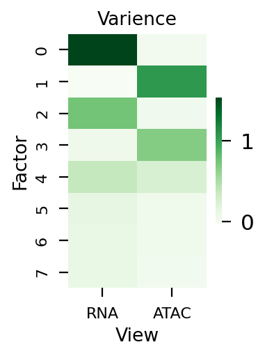

```python
pymofa_obj.get_r2()
```

pymofa_obj.get_r2()

|  | RNA | ATAC |
| --- | --- | --- |
| 0 | 1.531975 | 0.020675 |
| 1 | -0.036567 | 1.056309 |
| 2 | 0.751953 | 0.039987 |
| 3 | 0.060023 | 0.674215 |
| 4 | 0.364469 | 0.251295 |
| 5 | 0.141428 | 0.051458 |
| 6 | 0.114254 | 0.053613 |
| 7 | 0.119133 | 0.034315 |

### Visualize the correlation between factor and celltype

```python
pymofa_obj.plot_cor(rna1,'cell_type',figsize=(4,6))
```

pymofa_obj.plot_cor(rna1,'cell_type',figsize=(4,6))

```
(<Figure size 320x480 with 2 Axes>,
 <AxesSubplot: title={'center': 'Correlation'}, xlabel='Factor', ylabel='cell_type'>)
```

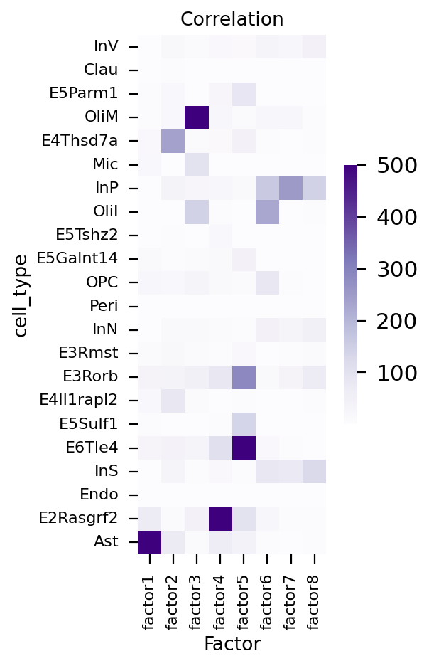

```python
pymofa_obj.get_cor(rna1,'cell_type')
```

pymofa_obj.get_cor(rna1,'cell_type')

|  | factor1 | factor2 | factor3 | factor4 | factor5 | factor6 | factor7 | factor8 |
| --- | --- | --- | --- | --- | --- | --- | --- | --- |
| InV | 0.665011 | 20.657980 | 9.248108 | 17.089494 | 13.422602 | 32.132796 | 24.124465 | 44.255535 |
| Clau | 2.826121 | 5.808516 | 0.811940 | 0.268856 | 0.263320 | 0.261479 | 0.105971 | 0.908162 |
| E5Parm1 | 7.532620 | 17.957307 | 1.763991 | 27.139456 | 84.494624 | 0.502745 | 0.651795 | 0.132044 |
| OliM | 6.513966 | 17.629268 | 500.000000 | 24.141743 | 10.914886 | 23.621465 | 25.395877 | 4.926897 |
| E4Thsd7a | 16.938637 | 237.595015 | 10.175490 | 13.044958 | 45.402276 | 4.448403 | 1.102767 | 5.383185 |
| Mic | 18.721245 | 0.863540 | 97.697177 | 1.925362 | 1.950863 | 1.756524 | 0.071363 | 0.533441 |
| InP | 3.293589 | 38.579983 | 26.957391 | 25.219145 | 15.585743 | 161.657573 | 250.170196 | 141.766482 |
| OliI | 2.847773 | 3.391799 | 141.002571 | 4.200228 | 2.875140 | 228.418422 | 0.743355 | 6.744291 |
| E5Tshz2 | 2.709568 | 7.122963 | 1.657839 | 18.795893 | 2.700763 | 0.392799 | 0.462671 | 2.154666 |
| E5Galnt14 | 14.255253 | 4.202316 | 9.685683 | 15.230670 | 46.138543 | 0.958545 | 1.906899 | 3.441217 |
| OPC | 23.475918 | 18.455308 | 32.199756 | 14.478467 | 10.162953 | 82.261963 | 5.433134 | 3.726258 |
| Peri | 0.658162 | 1.418508 | 0.884916 | 1.978547 | 3.519710 | 0.687741 | 0.444232 | 0.211925 |
| InN | 1.333910 | 14.820248 | 14.356910 | 10.069938 | 6.115415 | 45.999768 | 31.705707 | 51.326725 |
| E3Rmst | 10.885583 | 20.024174 | 11.668498 | 4.168142 | 17.267523 | 0.959733 | 4.561186 | 10.930971 |
| E3Rorb | 36.750410 | 38.807227 | 48.466332 | 81.247901 | 285.221588 | 14.008255 | 36.506786 | 69.163363 |
| E4Il1rapl2 | 18.191082 | 80.250141 | 11.056312 | 1.086077 | 6.790889 | 2.651834 | 1.754884 | 5.952761 |
| E5Sulf1 | 5.240678 | 1.483262 | 3.790759 | 6.827697 | 135.848121 | 1.140704 | 0.166260 | 0.283728 |
| E6Tle4 | 29.553202 | 39.878014 | 32.630424 | 104.177836 | 500.000000 | 16.817520 | 5.015146 | 0.432723 |
| InS | 3.389144 | 31.927599 | 6.973416 | 17.450485 | 6.059428 | 81.276278 | 74.919020 | 125.230026 |
| Endo | 0.638567 | 1.657187 | 0.245722 | 1.829868 | 0.430014 | 0.024523 | 0.465449 | 0.896513 |
| E2Rasgrf2 | 68.612084 | 10.432200 | 43.132372 | 500.000000 | 99.122213 | 23.616769 | 7.072289 | 4.607651 |
| Ast | 500.000000 | 72.170444 | 9.236814 | 67.929809 | 42.193385 | 5.108831 | 0.439351 | 4.559738 |

```python
pymofa_obj.plot_factor(rna1,'cell_type','Ast',figsize=(3,3),
                    factor1=1,factor2=3,)
```

pymofa_obj.plot_factor(rna1,'cell_type','Ast',figsize=(3,3), factor1=1,factor2=3,)

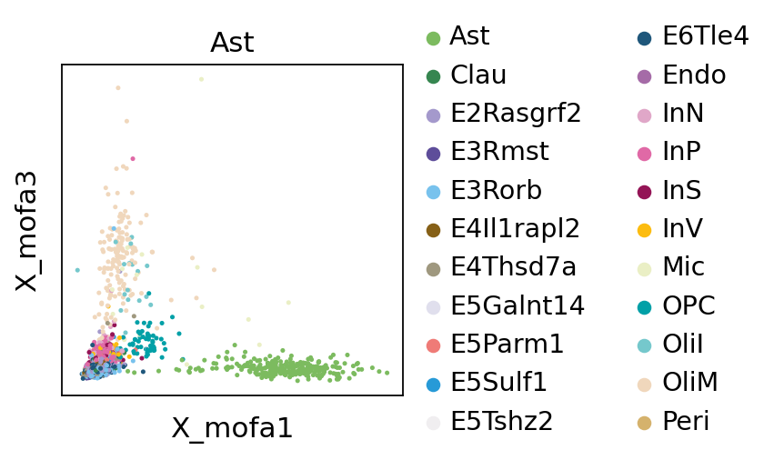

```
(<Figure size 240x240 with 1 Axes>,
 <AxesSubplot: title={'center': 'Ast'}, xlabel='X_mofa1', ylabel='X_mofa3'>)
```

### Visualize the factor in UMAP

To visualize the GLUE’s learned embeddings, we use the pymde package wrapperin scvi-tools. This is an alternative to UMAP that is GPU-accelerated.

You can use `sc.tl.umap` insteaded.

```python
from scvi.model.utils import mde
import scanpy as sc
sc.pp.neighbors(rna1, use_rep="X_glue", metric="cosine")
rna1.obsm["X_mde"] = mde(rna1.obsm["X_glue"])
```

from scvi.model.utils import mde import scanpy as sc sc.pp.neighbors(rna1, use_rep="X_glue", metric="cosine") rna1.obsm["X_mde"] = mde(rna1.obsm["X_glue"])

```
computing neighbors
    finished: added to `.uns['neighbors']`
    `.obsp['distances']`, distances for each pair of neighbors
    `.obsp['connectivities']`, weighted adjacency matrix (0:00:12)
```

```python
sc.pl.embedding(
    rna1,
    basis="X_mde",
    color=["factor1","factor3","cell_type"],
    frameon=False,
    ncols=3,
    #palette=ov.utils.pyomic_palette(),
    show=False,
    cmap='Greens',
    vmin=0,
)
```

sc.pl.embedding( rna1, basis="X_mde", color=["factor1","factor3","cell_type"], frameon=False, ncols=3, #palette=ov.utils.pyomic_palette(), show=False, cmap='Greens', vmin=0, )

```
[<AxesSubplot: title={'center': 'factor1'}, xlabel='X_mde1', ylabel='X_mde2'>,
 <AxesSubplot: title={'center': 'factor3'}, xlabel='X_mde1', ylabel='X_mde2'>,
 <AxesSubplot: title={'center': 'cell_type'}, xlabel='X_mde1', ylabel='X_mde2'>]
```

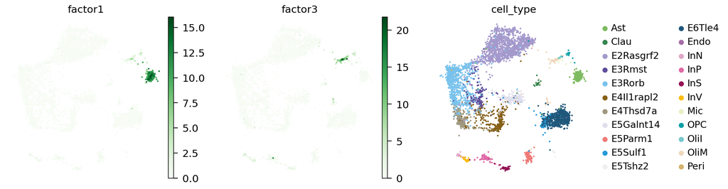

### Weights ranked

A visualization of factor weights familiar to MOFA and MOFA+ users is implemented with some modifications in `plot_weight_gene_d1`, `plot_weight_gene_d2`, and `plot_weights`.

```python
pymofa_obj.plot_weight_gene_d1(view='RNA',factor1=1,factor2=3,)
```

pymofa_obj.plot_weight_gene_d1(view='RNA',factor1=1,factor2=3,)

```
(<Figure size 240x240 with 1 Axes>,
 <AxesSubplot: xlabel='factor_1', ylabel='factor_3'>)
```

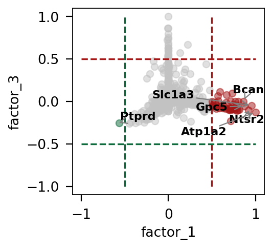

```python
pymofa_obj.plot_weights(view='RNA',factor=1,
                        ascending=False)
```

pymofa_obj.plot_weights(view='RNA',factor=1, ascending=False)

```
(<Figure size 240x320 with 1 Axes>,
 <AxesSubplot: title={'center': 'factor_1'}, xlabel='Feature rank', ylabel='Weight'>)
```

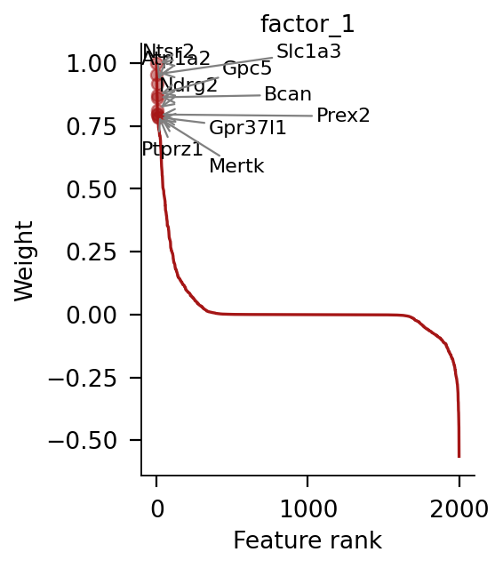

### Weights heatmap

While trying to annotate factors, a global overview of top features defining them could be helpful.

```python
pymofa_obj.plot_top_feature_heatmap(view='RNA')
```

pymofa_obj.plot_top_feature_heatmap(view='RNA')

```
ranking genes
    finished: added to `.uns['rank_genes_groups']`
    'names', sorted np.recarray to be indexed by group ids
    'scores', sorted np.recarray to be indexed by group ids
    'logfoldchanges', sorted np.recarray to be indexed by group ids
    'pvals', sorted np.recarray to be indexed by group ids
    'pvals_adj', sorted np.recarray to be indexed by group ids (0:00:00)
WARNING: dendrogram data not found (using key=dendrogram_Factor). Running `sc.tl.dendrogram` with default parameters. For fine tuning it is recommended to run `sc.tl.dendrogram` independently.
WARNING: You’re trying to run this on 2000 dimensions of `.X`, if you really want this, set `use_rep='X'`.
         Falling back to preprocessing with `sc.pp.pca` and default params.
computing PCA
    with n_comps=15
    finished (0:00:00)
Storing dendrogram info using `.uns['dendrogram_Factor']`
```

```
{'mainplot_ax': <AxesSubplot: >,
 'group_extra_ax': <AxesSubplot: >,
 'gene_group_ax': <AxesSubplot: >,
 'color_legend_ax': <AxesSubplot: title={'center': 'Mean expression\nin group'}>}
```

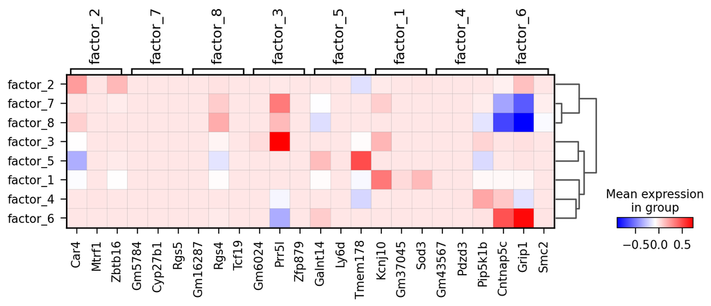